# Customer Segmenting

gvant

2023-06-28

## Loading Dataset

```r
telco <- data.frame(read.csv("telco.csv"))
head(telco)
```

```
##   customerID gender SeniorCitizen Partner Dependents tenure PhoneService
## 1 7590-VHVEG Female             0     Yes         No      1           No
## 2 5575-GNVDE   Male             0      No         No     34          Yes
## 3 3668-QPYBK   Male             0      No         No      2          Yes
## 4 7795-CFOCW   Male             0      No         No     45           No
## 5 9237-HQITU Female             0      No         No      2          Yes
## 6 9305-CDSKC Female             0      No         No      8          Yes
##      MultipleLines InternetService OnlineSecurity OnlineBackup DeviceProtection
## 1 No phone service             DSL             No          Yes               No
## 2               No             DSL            Yes           No              Yes
## 3               No             DSL            Yes          Yes               No
## 4 No phone service             DSL            Yes           No              Yes
## 5               No     Fiber optic             No           No               No
## 6              Yes     Fiber optic             No           No              Yes
##   TechSupport StreamingTV StreamingMovies       Contract PaperlessBilling
## 1          No          No              No Month-to-month              Yes
## 2          No          No              No       One year               No
## 3          No          No              No Month-to-month              Yes
## 4         Yes          No              No       One year               No
## 5          No          No              No Month-to-month              Yes
## 6          No         Yes             Yes Month-to-month              Yes
##               PaymentMethod MonthlyCharges TotalCharges Churn
## 1          Electronic check          29.85        29.85    No
## 2              Mailed check          56.95      1889.50    No
## 3              Mailed check          53.85       108.15   Yes
## 4 Bank transfer (automatic)          42.30      1840.75    No
## 5          Electronic check          70.70       151.65   Yes
## 6          Electronic check          99.65       820.50   Yes
```

```r
summary(is.na(telco))
```

```
##  customerID        gender        SeniorCitizen    Partner
##  Mode :logical   Mode :logical   Mode :logical   Mode :logical
##  FALSE:7043      FALSE:7043      FALSE:7043      FALSE:7043
##
##  Dependents        tenure        PhoneService    MultipleLines
##  Mode :logical   Mode :logical   Mode :logical   Mode :logical
##  FALSE:7043      FALSE:7043      FALSE:7043      FALSE:7043
##
##  InternetService OnlineSecurity  OnlineBackup    DeviceProtection
##  Mode :logical   Mode :logical   Mode :logical   Mode :logical
##  FALSE:7043      FALSE:7043      FALSE:7043      FALSE:7043
##
##  TechSupport     StreamingTV     StreamingMovies  Contract
##  Mode :logical   Mode :logical   Mode :logical   Mode :logical
##  FALSE:7043      FALSE:7043      FALSE:7043      FALSE:7043
##
##  PaperlessBilling PaymentMethod   MonthlyCharges  TotalCharges
##  Mode :logical    Mode :logical   Mode :logical   Mode :logical
##  FALSE:7043       FALSE:7043      FALSE:7043      FALSE:7032
##                                                   TRUE :11
##    Churn
##  Mode :logical
##  FALSE:7043
##
```

As we can see, the data here is pretty complete, but there are some null values in Total Charges I’d like to investigate.

```r
telco[is.na(telco$TotalCharges),]
```

```
##      customerID gender SeniorCitizen Partner Dependents tenure PhoneService
## 489  4472-LVYGI Female             0     Yes        Yes      0           No
## 754  3115-CZMZD   Male             0      No        Yes      0          Yes
## 937  5709-LVOEQ Female             0     Yes        Yes      0          Yes
## 1083 4367-NUYAO   Male             0     Yes        Yes      0          Yes
## 1341 1371-DWPAZ Female             0     Yes        Yes      0           No
## 3332 7644-OMVMY   Male             0     Yes        Yes      0          Yes
## 3827 3213-VVOLG   Male             0     Yes        Yes      0          Yes
## 4381 2520-SGTTA Female             0     Yes        Yes      0          Yes
## 5219 2923-ARZLG   Male             0     Yes        Yes      0          Yes
## 6671 4075-WKNIU Female             0     Yes        Yes      0          Yes
## 6755 2775-SEFEE   Male             0      No        Yes      0          Yes
##         MultipleLines InternetService      OnlineSecurity        OnlineBackup
## 489  No phone service             DSL                 Yes                  No
## 754                No              No No internet service No internet service
```

[output cut: 45 more lines]

Given that the “tenure” column is zero for all of the null values for Total Charges, it is safe to assume that these are brand new customers. Therefore, it is best to replace these null values with “0” since they haven’t yet accumulated any charges. It is also better to appropriately apply “0,1” coding to binary variables, as well as correctly list applicable categories as factors.

```r
telco$TotalCharges[is.na(telco$TotalCharges)] <- 0

# binary coding
telco[,c(4,5,7,8,10:15,17,21)] <- as.numeric(ifelse(telco[,c(4,5,7,8,10:15,17,21)]=="Yes", 1, 0))

# categorical / factorized coding
for (i in c(2,9,16,18)){
  telco[,i] <- as.factor(telco[,i])
}
```

Now that the data has been fixed, the first method of analysis can begin. The goal here is to segment customers based on clusters. However, we are not sure which kinds of clusters we should make or how many. We can start with K-Proto clustering and use the elbow method in order to figure out an optimal number of clusters.We can also test if using the Gower Dissimilarity method makes a difference.

[output not shown]

[output cut: 97 more lines]

[output not shown]

```
## # A tibble: 9 × 3
##   Centers `SS for K-Proto` `SS for K-Proto (with Gower)`
##     <int>            <dbl>                         <dbl>
## 1       2     15619546660.                        40786.
## 2       3     11237395734.                        38949.
## 3       4      9501386148.                        37333.
## 4       5      8469614208.                        32990.
## 5       6      7593367871.                        32495.
## 6       7      7190034658.                        30595.
## 7       8      7488483433.                        29518.
## 8       9      6397331645.                        30092.
## 9      10      5888530073.                        28659.
```

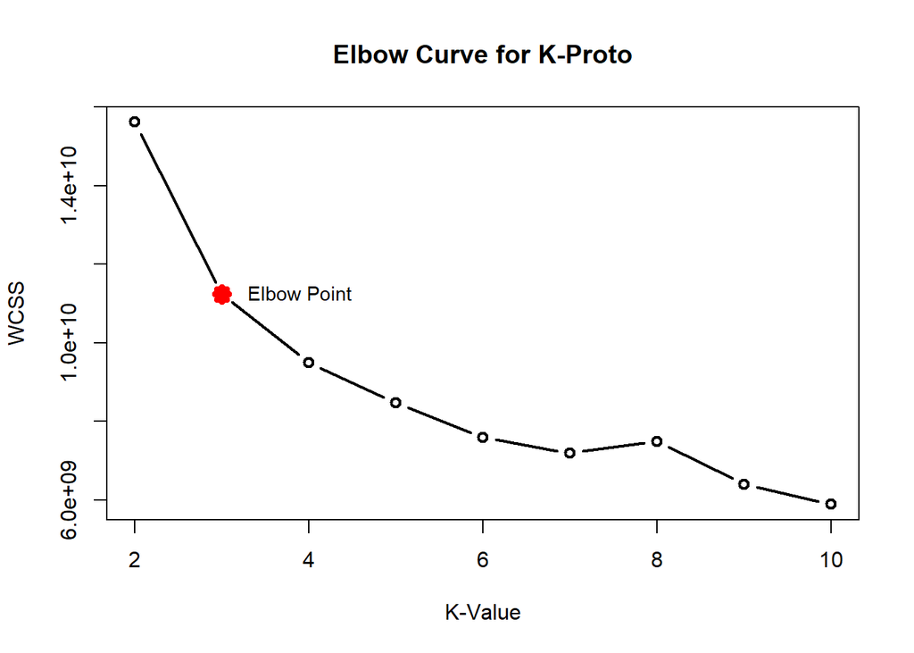

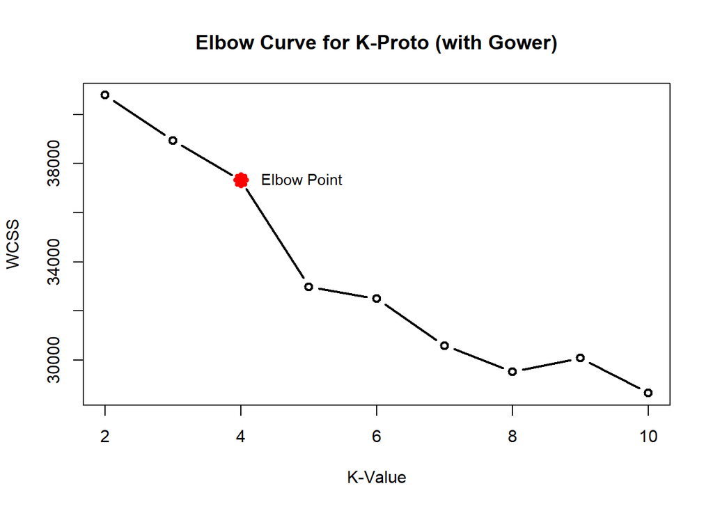

Both curves show a level of ambiguity with respect to the elbow point, which means that a bit of intuition can be applied here. We know that we would like to keep the number of categories small (all other things considered). This is because if the company were to run targeted advertisements, it would be more cost-efficient to apply a small number of pricing models: one for each ‘type’ of customer.

Let us examine the groups more closely.

```r
k_opt <- kproto(telco[,-1], 3)
```

[output not shown]

```r
kg_opt <- kproto(telco[,-1], 4)
```

[output not shown]

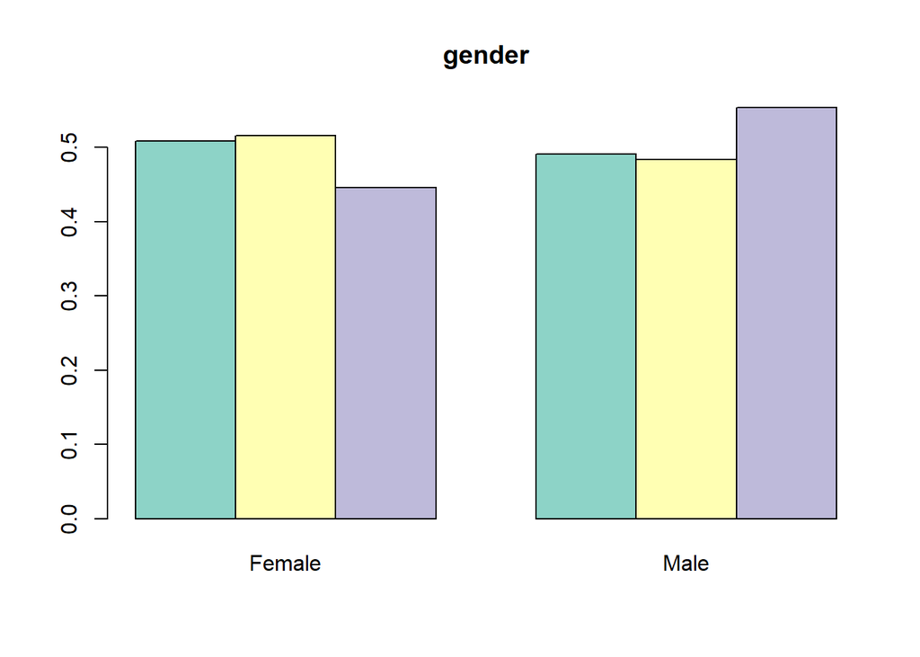

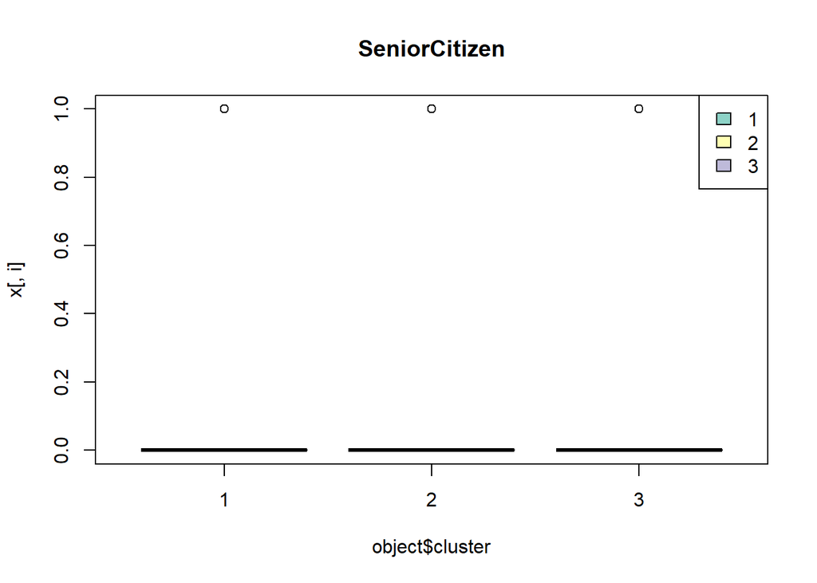

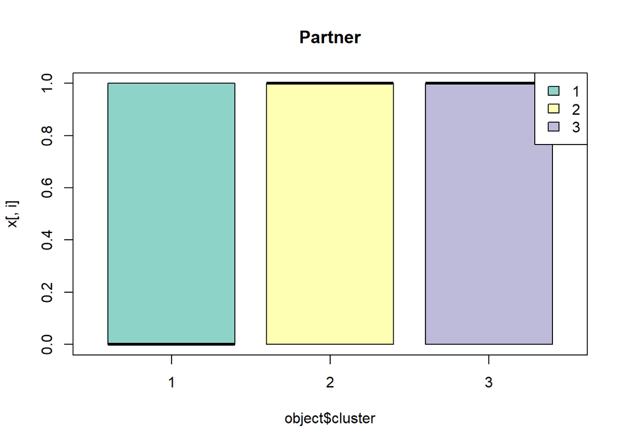

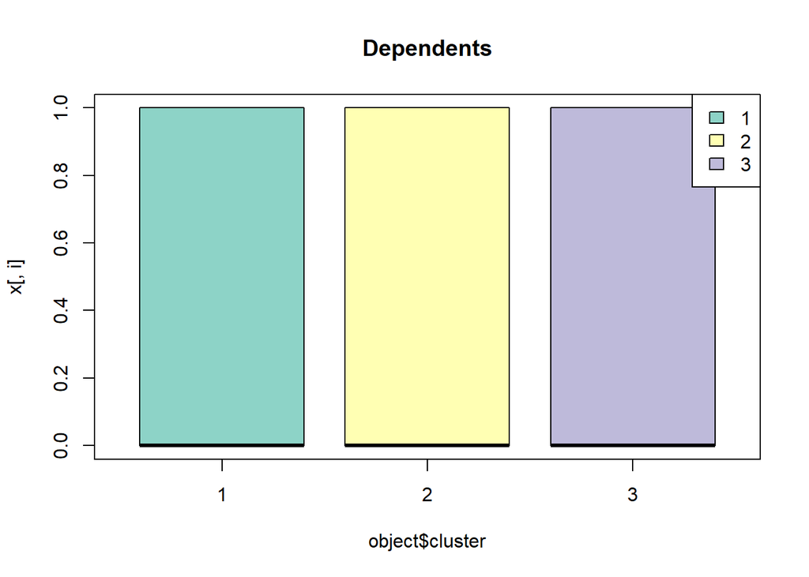

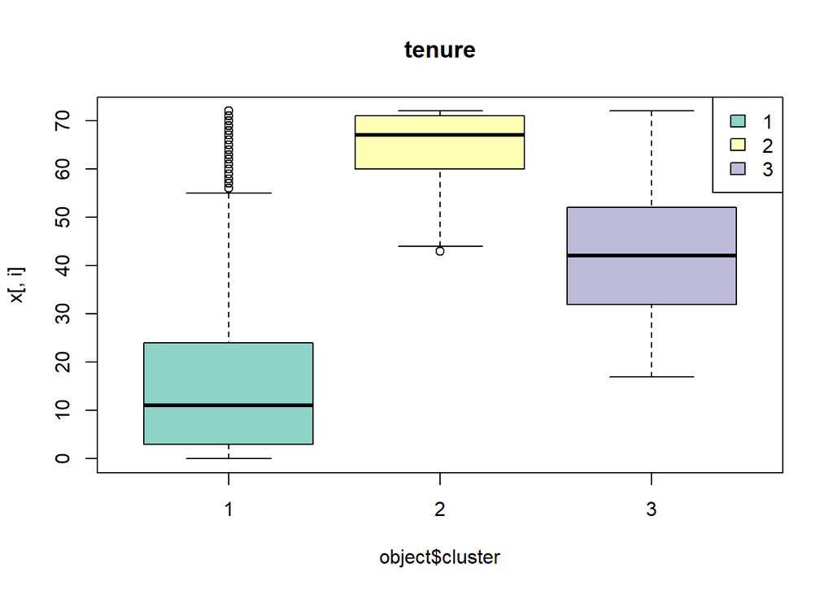

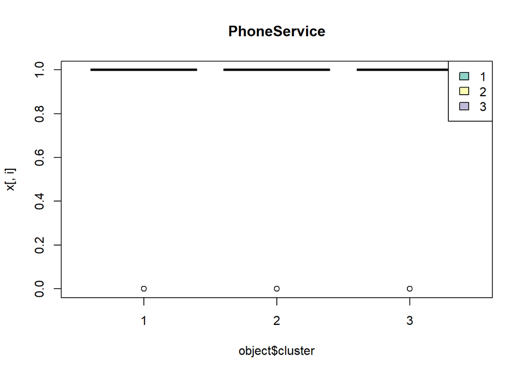

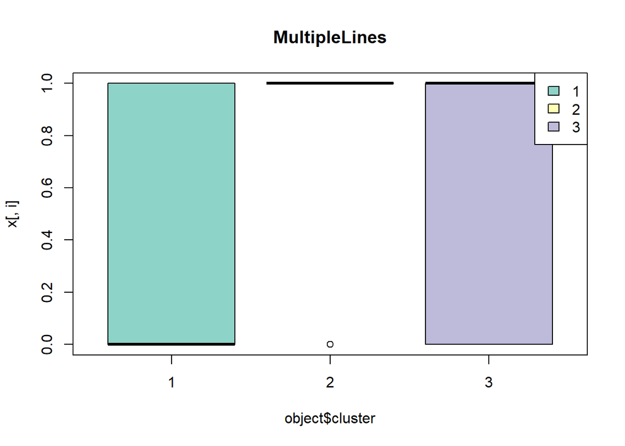

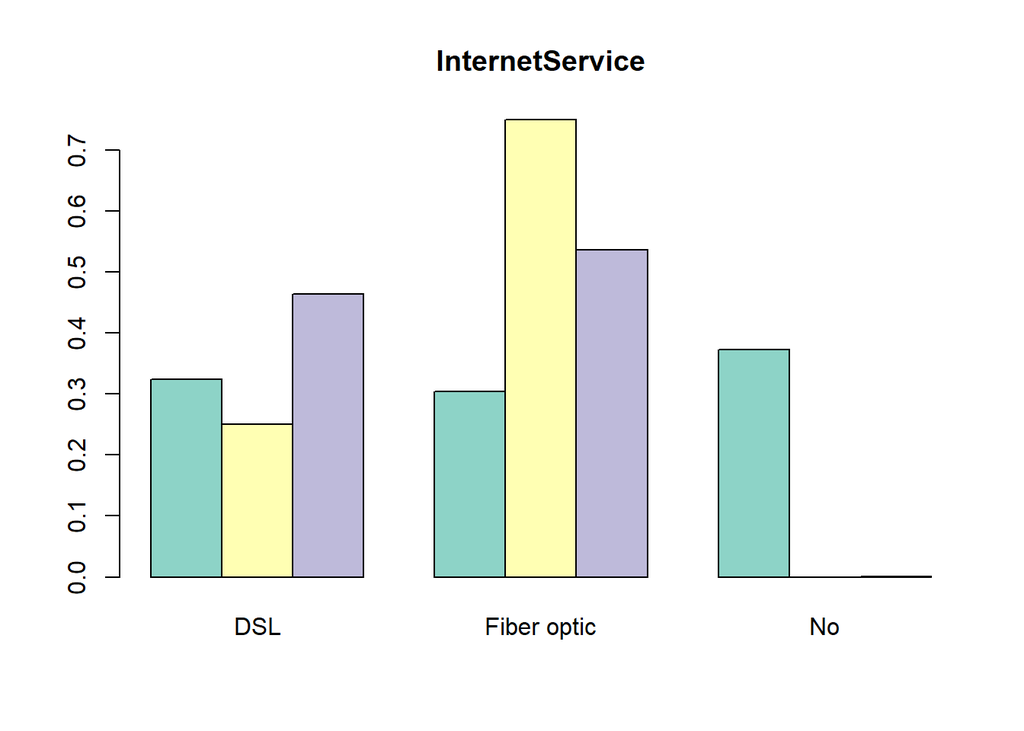

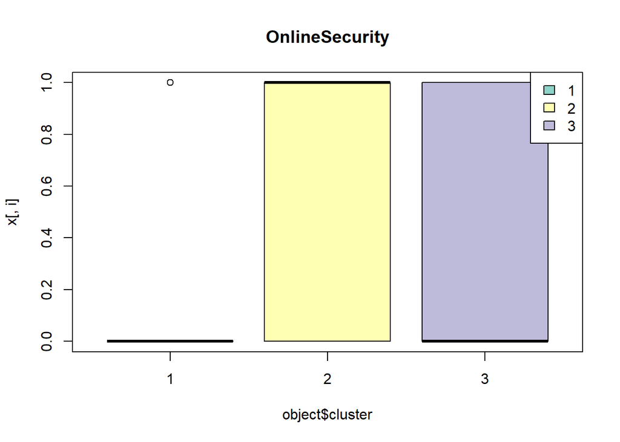

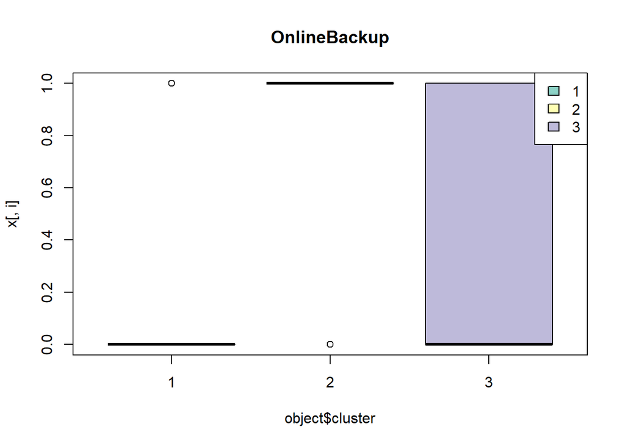

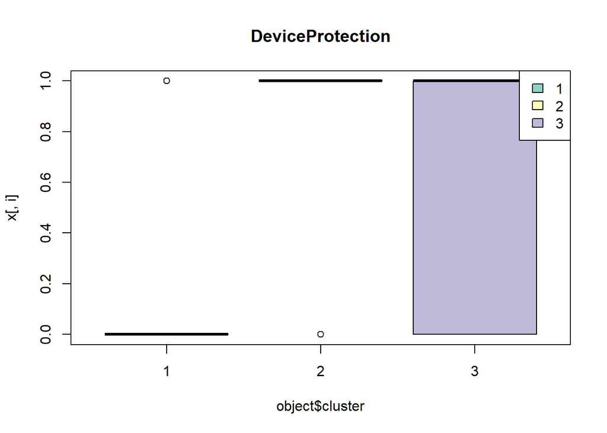

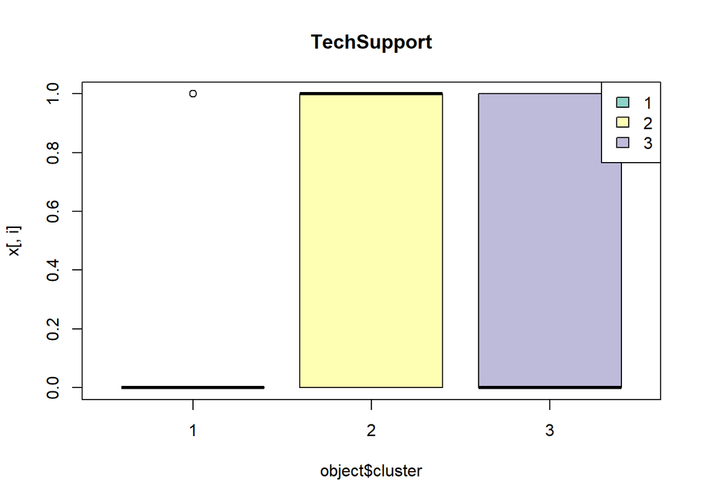

[8 more figures not shown]

```r
clprofiles(k_opt, telco[,-1])
```

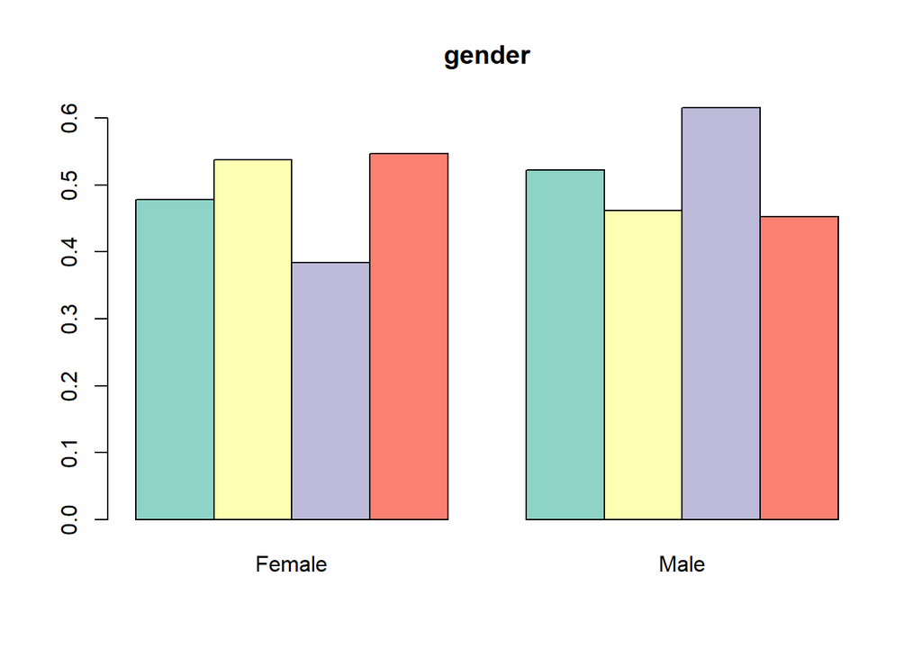

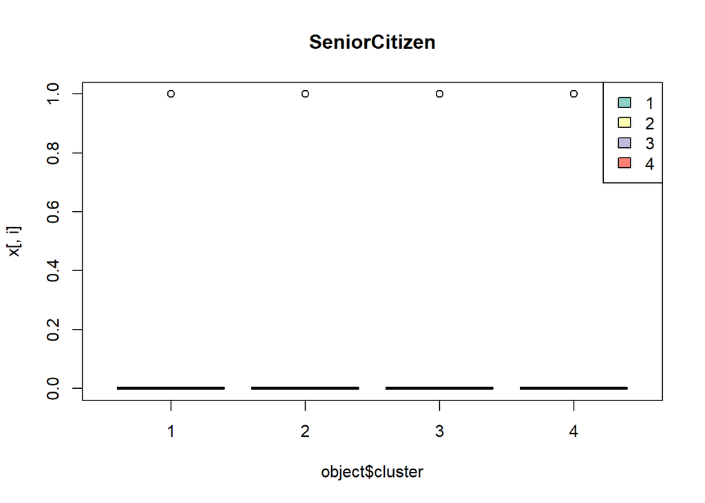

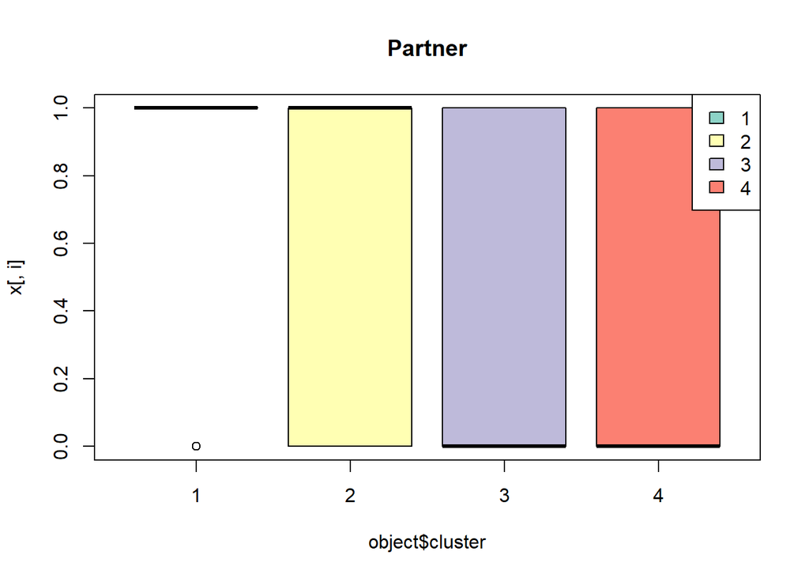

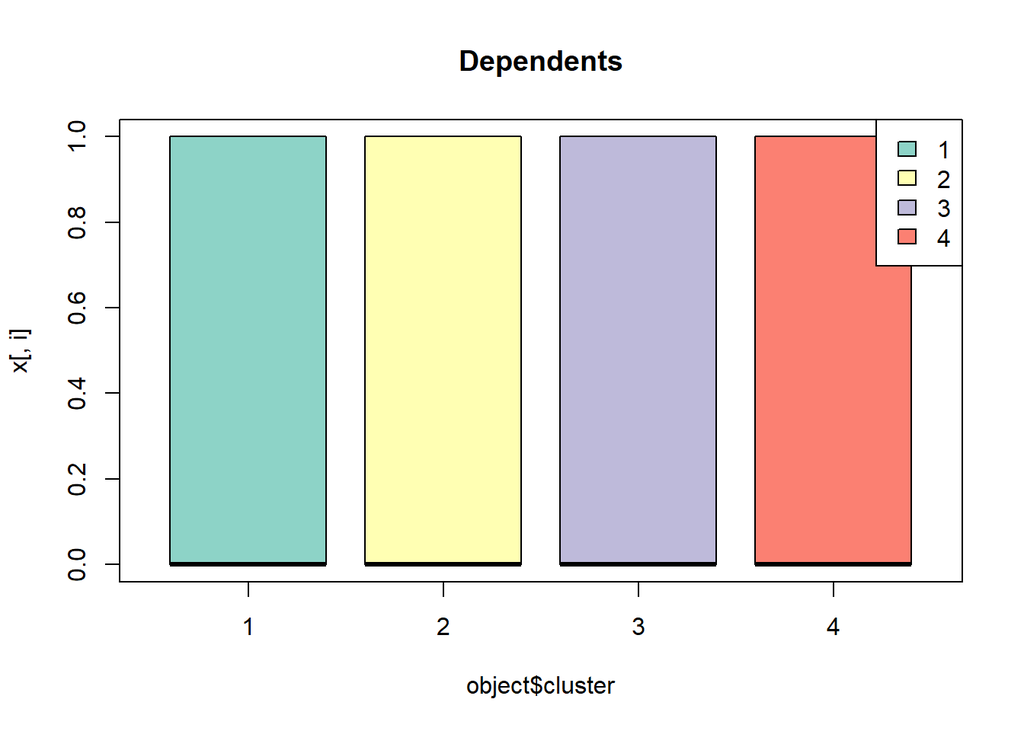

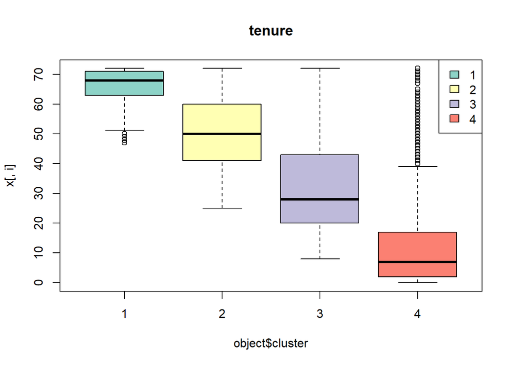

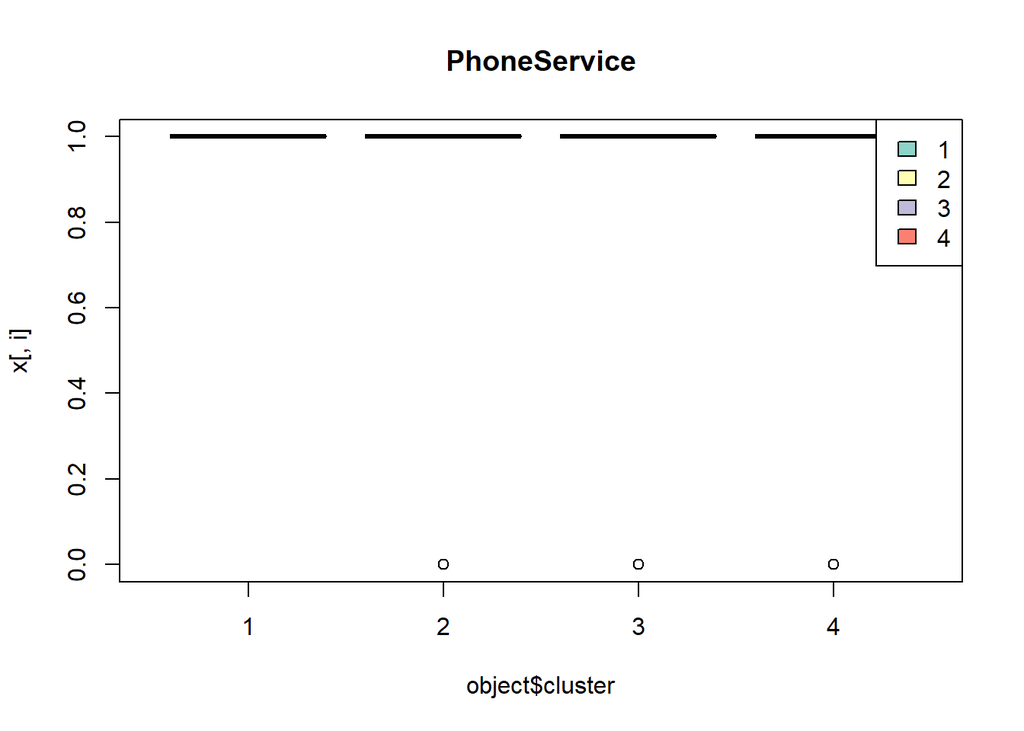

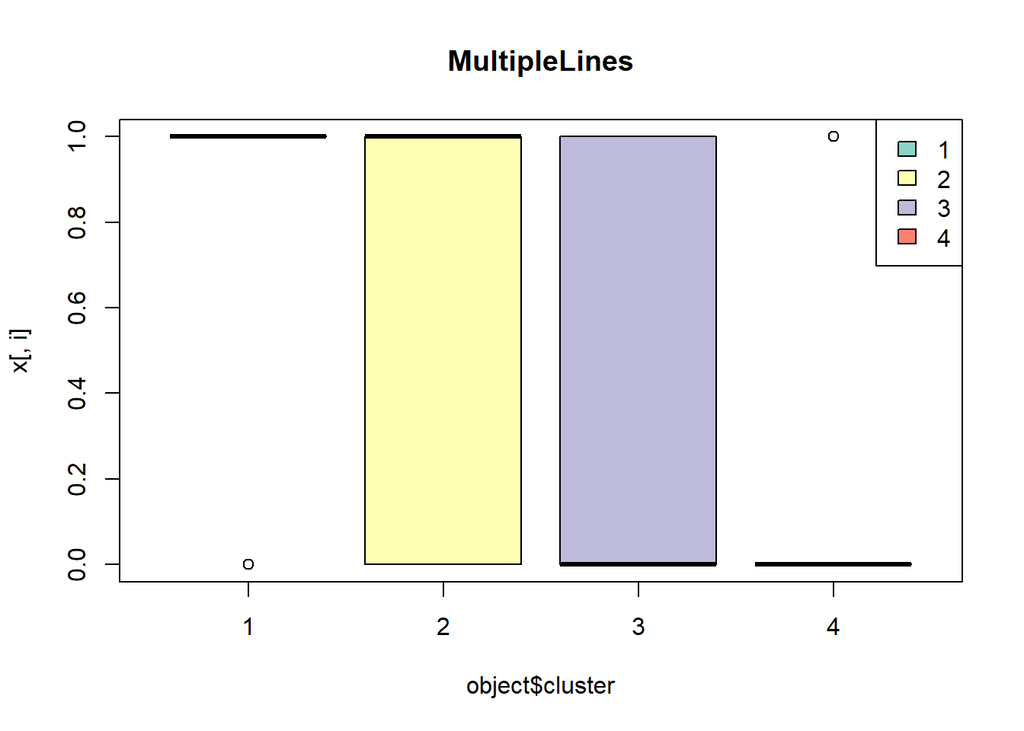

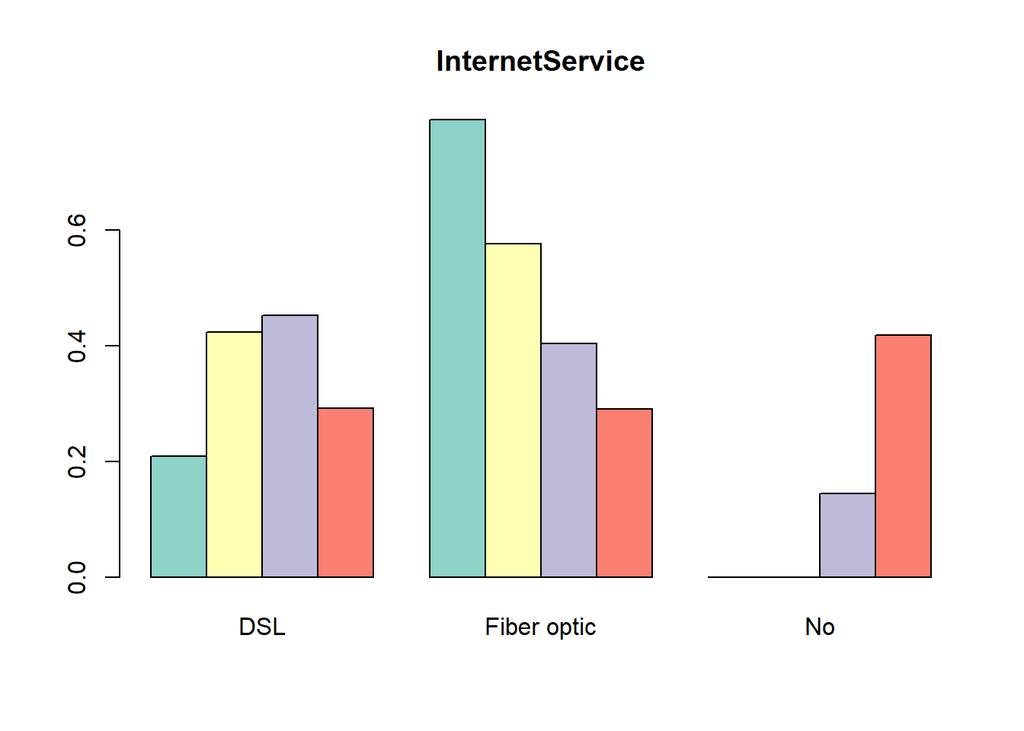

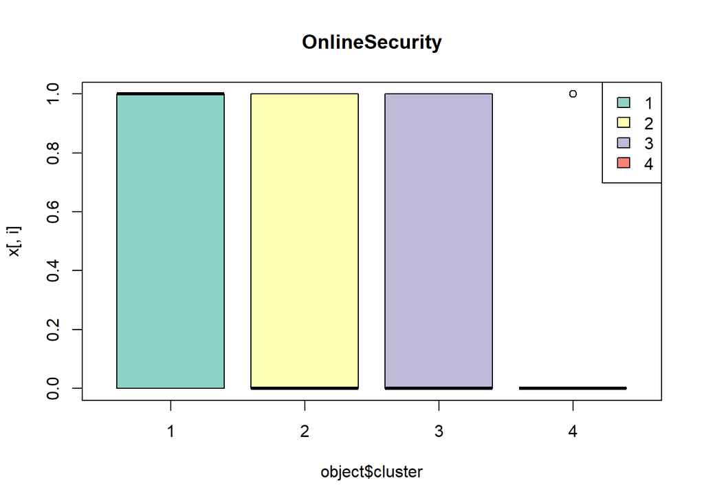

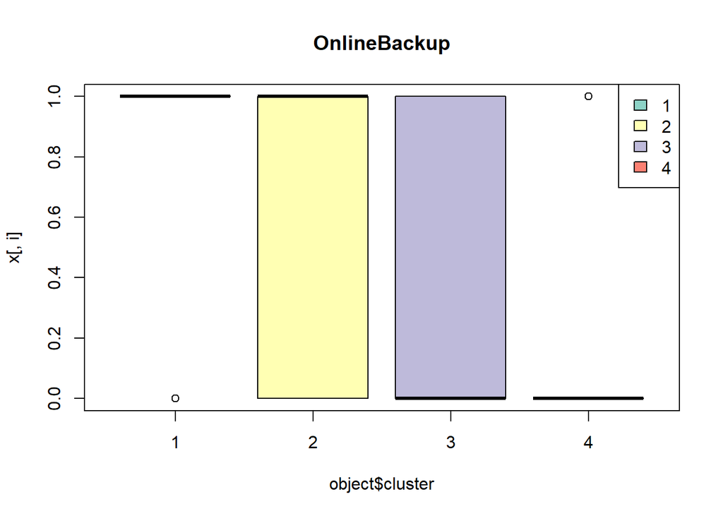

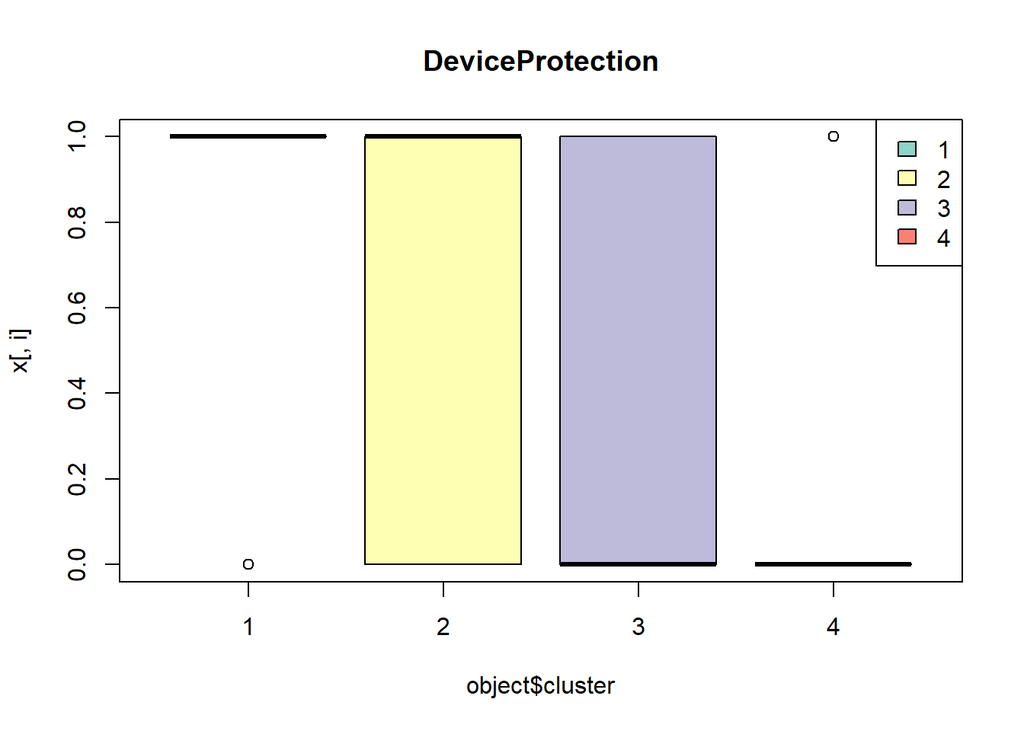

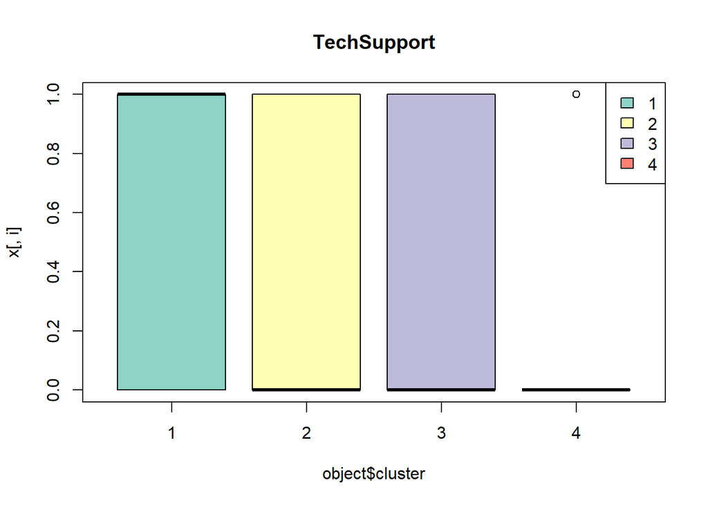

[8 more figures not shown]

```r
clprofiles(kg_opt, telco[,-1])
```

After a thorough analysis of both sets of graphs, I see a similar trend being conveyed. Adding a fourth category does not appear to add any more clarity or distinction to the model, so the three-category model will suffice.

```r
centers <- data.frame(k_opt$centers)
proportions <- tibble("Cluster"=c(1:3),"Proportion"=table(k_opt$cluster)/nrow(telco))

vars <- c()
for (i in 1:ncol(centers)){
  if (class(centers[,i]) == "numeric"){
    vars[i] <- sd(centers[,i])
  }else{
    vars[i] <- NA
  }
}

total.variance <- data.frame(t(rbind(centers,vars)))
total.variance <- data.frame(row.names(total.variance), total.variance)
colnames(total.variance) = c("Variable", "Cluster1", "Cluster2", "Cluster3", "SDev")
rownames(total.variance) = NULL

total.variance <- total.variance[order(total.variance$SDev, decreasing=T),]

proportions
```

```
## # A tibble: 3 × 2
##   Cluster Proportion
##     <int> <table[1d]>
## 1       1 0.5817123
## 2       2 0.1818827
## 3       3 0.2364049
```

```r
tibble(total.variance)
```

```
## # A tibble: 20 × 5
##    Variable         Cluster1           Cluster2                Cluster3    SDev
##    <chr>            <chr>              <chr>                   <chr>       <chr>
##  1 TotalCharges     " 663.4751"        6262.0473               3192.9302   2803…
##  2 MonthlyCharges   "49.12963"         97.28544                78.20411    24.2…
##  3 tenure           "18.09617"         64.49415                42.78258    23.2…
##  4 StreamingMovies  "0.1911155"        0.8103044               0.5471471   0.31…
##  5 StreamingTV      "0.1891628"        0.8017174               0.5435435   0.30…
##  6 DeviceProtection "0.1501098"        0.7556596               0.5039039   0.30…
##  7 OnlineBackup     "0.1569441"        0.7501952               0.4954955   0.29…
##  8 MultipleLines    "0.2650720"        0.8165496               0.5039039   0.27…
##  9 TechSupport      "0.1393703"        0.6104606               0.4150150   0.23…
## 10 OnlineSecurity   "0.1418111"        0.5886027               0.4108108   0.22…
## 11 Partner          "0.3749085"        0.7416081               0.5501502   0.18…
## 12 PaperlessBilling "0.52477423"       0.70335675              0.67267267  0.09…
## 13 Churn            "0.31925799"       0.13270882              0.23483483  0.09…
## 14 PhoneService     "0.89065170"       0.99141296              0.86606607  0.06…
## 15 SeniorCitizen    "0.12545765"       0.21155347              0.21441441  0.05…
## 16 Dependents       "0.28655113"       0.34348165              0.29789790  0.03…
## 17 gender           "Female"           Female                  Male        <NA>
## 18 InternetService  "No"               Fiber optic             Fiber optic <NA>
## 19 Contract         "Month-to-month"   Two year                Month-to-m… <NA>
## 20 PaymentMethod    "Electronic check" Credit card (automatic) Electronic… <NA>
```

Here’s a table sorted by standard deviation, which tells us the most significant categories sorted by standard deviation. We can see that what sets the categories apart most are the total and monthly charges, as well as how long each customer has been a member.Here, we can create a few categories for customers using the averages from the data.

## The Titan

**Average Monthly Charges: $96** **Average Tenure: 5+ Years** Characteristics: * Long-term contracts * Has full bundle complete with streaming * Has multiple phone lines * Very unlikely to churn

## The Casual Customer

**Average Monthly Charges: $77** **Average Tenure: 3.5 Years** Characteristics: * One-year and Month-to-month contracts * Has internet bundle, but may or may not have fiber optic * Sometimes opts for streaming bundle

## The Nomad

### Cluster One

**Average Monthly Charges: $48** **Average Tenure: 1.5 Years** Characteristics: * Month-to-month contracts * Hardly utilizes company bundles * High churn rate * Usually younger